# Lecture 11: Regression Discontinuity

EEFE 530

Daniel Brent

# Schedule

## Last time

- Synthetic control

## Today

- Regression discontinuity *

* These notes largely follow notes from [Ed Rubin](https://edrub.in/) via [Michael Anderson](https://are.berkeley.edu/~mlanderson/ARE_Website/Home.html), [Imbens and Lemieux (2008)](https://www.sciencedirect.com/science/article/pii/S0304407607001091)

## Upcoming

- Replication and extension DID
- Problem set (RD)

# Readings

## Regression Discontinuity

- *MHE* Ch. 6
- Mixtape Ch. 6
- Effect Ch. 20
- Imbens and Lemieux (2008), [Regression discontinuity designs: A guide to practice](https://www.sciencedirect.com/science/article/pii/S0304407607001091)
- Lee and Lemieux (2010), [Regression Discontinuity Designs in Economics](https://www.aeaweb.org/articles?id=10.1257/jel.48.2.281)
- Cattaneo and Titiunik (2022), [Regression Discontinuity Designs](https://cattaneo.princeton.edu/papers/Cattaneo-Titiunik_2022_ARE.pdf)
- [Robust data driven RD - Cattaneo and coauthors](https://rdpackages.github.io/)

## Regression Discontinuity: Application

- [Chen et al. (2013)](https://www.pnas.org/doi/10.1073/pnas.1616784114)
- [Gelman Blog #1](https://statmodeling.stat.columbia.edu/2013/08/05/evidence-on-the-impact/)
- [Gelman Blog #2](https://statmodeling.stat.columbia.edu/2013/08/07/i-doubt-they-cheated/)
- [Gelman & Imben (2018)](https://www.tandfonline.com/doi/full/10.1080/07350015.2017.1366909)
- [Chen et al. (2018)](https://www.pnas.org/doi/10.1073/pnas.1300018110)
- [Gelman Blog #3](https://statmodeling.stat.columbia.edu/2018/08/02/38160/)

# Regression Discontinuity

## Setup

We’re still in the game of estimating the effect of a potentially endogenous binary treatment $\text{D}_{i}$ on an outcome $\text{Y}_{i}$.

Regression discontinuity (RD) offers a particularly clear/clean research design based upon an arbitrary threshold (the *discontinuity*).

That said, most RDs boil down to an implementation of IV.

In addition, while RD very popular in modern applied econometrics there are some important limitations.

## Our framework

Back to our potential-outcome framework.

We want to know the effect of $\text{D}_{i}$ on $\text{Y}_{i}$.
$$\begin{align}
\text{Y}_{i} = \text{D}_{i} \text{Y}_{1i} + (1-\text{D}_{i}) \text{Y}_{0i}
\end{align}$$

New: Suppose $\text{D}_{i}$ is determined* by whether some variable $\text{X}_{i}$ crosses a threshold $c$ (the discontinuity).

The variable $\text{X}_{i}$ need not be randomly assigned—we will assume it is not (*i.e.*, $\text{X}_{i}$ correlates with $\text{Y}_{0i}$ and $\text{Y}_{1i}$).

We will assume that $\text{Y}_{0i}$ and $\text{Y}_{1i}$ vary smoothly in $\text{X}_{i}$.

* At least in part.

## Examples

We often apply regression-discontinuity designs in setting with some arbitrary threshold embedded within some bureaucratic decision.

- An elector candidate wins if her vote share exceeds her competitors.
- A policy holds based on some strict income threshold.
- Antidiscrimination laws only apply to firms with >15 employees.
- Prisoners are eligible for early parole if some score exceeds a threshold.
- An individual is eligible for Medicare if her age is at least 65.
- You get a ticket if your speed exceeds the speed limit.
- Fifteen-percent discount at Sizzler if your age exceeds 60.
- Counties with PM2.5 > 35 μg/m3 are *out of attainment*.

In some cases, “treatment” is definite once we exceed the threshold.

## Sharp *vs.* fuzzy

We distinguish RDs by whether the threshold automatically assigns treatment or not.

In sharp RDs, individuals move from control to treatment when their $\text{X}_{i}$ passes our threshold $c$, *i.e.*, $\text{D}_{i}$ switches from 0 to 1 when $\text{X}_{i}$ moves across $c$.

Ex: a politician wins an election when the difference between her vote share and her competitor’s vote share exceeds zero.

In fuzzy RDs, the *probability of treatment* $\mathop{\text{Pr}}\left( \text{D}_{i}=1 \right)$ discontinuously jumps at the threshold $c$, but it does not move from 0 to 1.

Ex: crossing some GRE threshold discontinuously increases your chances of getting into some grad schools (but doesn’t guarantee admittance). Or your chances of getting tenure jumps when you have a certain number of publications.

# Sharp RDs

## Setup

With sharp regression discontinuity, the probability of treatment changes from 0 to 1 as $\text{X}_{i}$ moves across threshold $c$.

Thus, treatment status totally depends upon whether $\text{X}_{i}\geq c$, *i.e.*,

$$\begin{align}
\text{D}_{i} = \mathbb{I}\!\left\{ \text{X}_{i}\geq c \right\}
\end{align}$$

To estimate the causal effect of $\text{D}_{i}$ on $\text{Y}_{i}$, we compare the mean of $\text{Y}_{i}$ just *above* the threshold to the mean of $\text{Y}_{i}$ just *below* the threshold.

Our identifying assumption is that observations just above and just below the threshold are very similar. Therefore, an observation just below the threshold serves as a valid counterfactual for an observation just above the threshold.

## More formally

We can write the comparison of means at the threshold as

$\lim_{x\downarrow c} \mathop{E}\left[ \text{Y}_{i}\mid \text{X}_{i} = x \right] - \lim_{x\uparrow c} \mathop{E}\left[ \text{Y}_{i}\mid \text{X}_{i} = x \right]$

$=\lim_{x\downarrow c} \mathop{E}\left[ \color{#0073e6}{\text{Y}_{1i}}\mid \text{X}_{i} = x \right] - \lim_{x\uparrow c} \mathop{E}\left[ \color{#006400}{\text{Y}_{0i}}\mid \text{X}_{i} = x \right]$

$=\tau_\text{SRD}$

Assumption $\mathop{E}\left[ \color{#0073e6}{\text{Y}_{1i}} \mid \text{X}_{i} = x\right]$ and $\mathop{E}\left[ \color{#006400}{\text{Y}_{0i}} \mid \text{X}_{i} = x \right]$ are continuous in $x$.

$\implies \tau_\text{SRD} = \mathop{E}\left[ \color{#0073e6}{\text{Y}_{1i}} - \color{#006400}{\text{Y}_{0i}} \mid \text{X}_{i} = c \right]$

*I.e.*, Because we don’t observe $\color{#006400}{\text{Y}_{0i}}$ for treated individuals, we extrapolate $\mathop{E}\left[ \color{#006400}{\text{Y}_{0i}} \mid \text{X}_{i} = c - \varepsilon \right]$ to $\mathop{E}\left[ \color{#006400}{\text{Y}_{0i}} \mid \text{X}_{i} = x + \varepsilon \right]$ for small $\varepsilon$.

## Estimation

Thus, we estimate
$$\begin{align}
\tau_\text{SRD} = \lim_{x\downarrow c} \mathop{E}\left[ \text{Y}_{i} - \text{X}_{i} = x \right] - \lim_{x\uparrow c} \mathop{E}\left[ \text{Y}_{i} \mid \text{X}_{i} = x \right]
\end{align}$$
as the difference between two regression functions estimated “near” $c$.

We must stay “near” $c$ to minimize the bias from extrapolating $\mathop{E}\left[ \color{#006400}{\text{Y}_{0i}} \mid \text{X}_{i} = c - \varepsilon \right]$ to $\mathop{E}\left[ \color{#006400}{\text{Y}_{0i}} \mid \text{X}_{i} = c + \varepsilon \right]$ (and assuming continuity).

Ex. Is there an effect of a political party winning an election on that party’s likelihood of winning the following election?

Is there a benefit of incumbency (at the party level)?*

* [Lee (2008)](https://www.sciencedirect.com/science/article/pii/S0304407607001121) addresses this question via RD. [Caughey and Sekhon (2011)](https://doi.org/10.1093/pan/mpr032) discuss RD in this setting.

Let’s start with $\color{#006400}{\mathop{E}\left[ \text{Y}_{0i} \mid \text{X}_{i} \right]}$

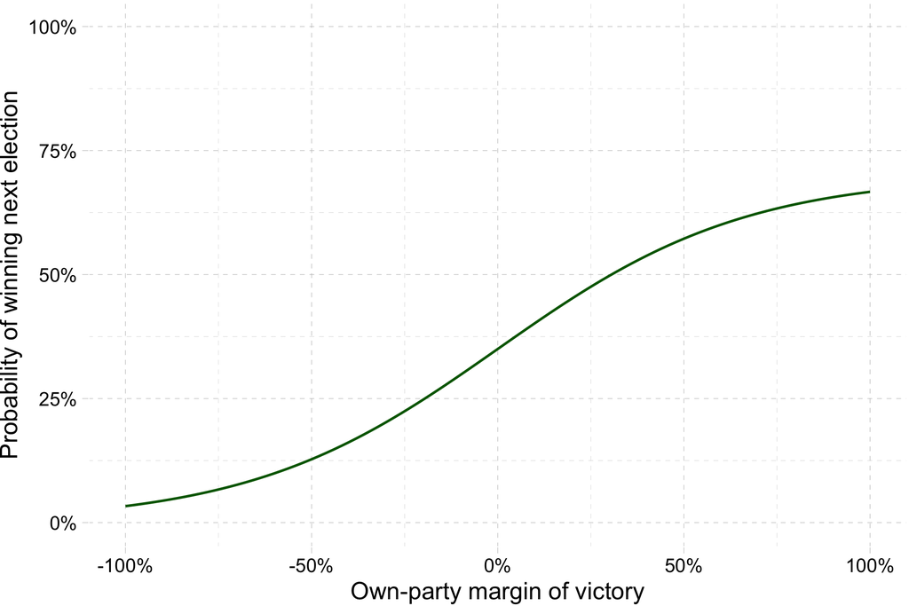

Let’s start with $\color{#006400}{\mathop{E}\left[ \text{Y}_{0i} \mid \text{X}_{i} \right]}$ and $\color{#0073e6}{\mathop{E}\left[ \text{Y}_{1i} \mid \text{X}_{i} \right]}$.

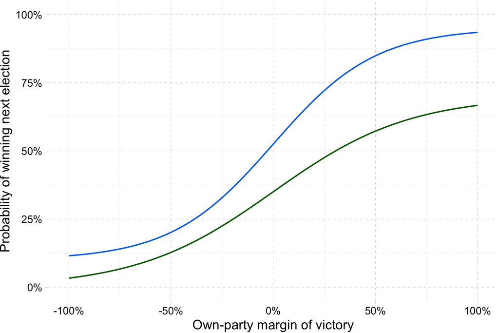

You only win an election if your margin of victory exceeds zero.

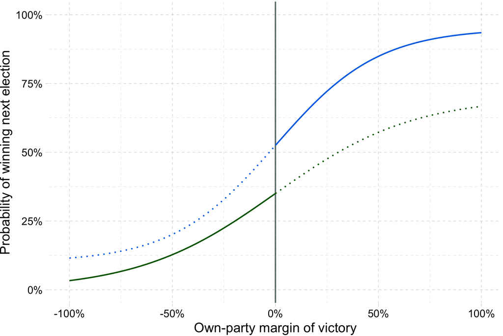

$\color{#0073e6}{\mathop{E}\left[ \text{Y}_{1i} \mid \text{X}_{i} \right]} - \color{#006400}{\mathop{E}\left[ \text{Y}_{0i} \mid \text{X}_{i} \right]}$ at the discontinuity gives $\color{#FFA500}{\tau_\text{SRD}}$.

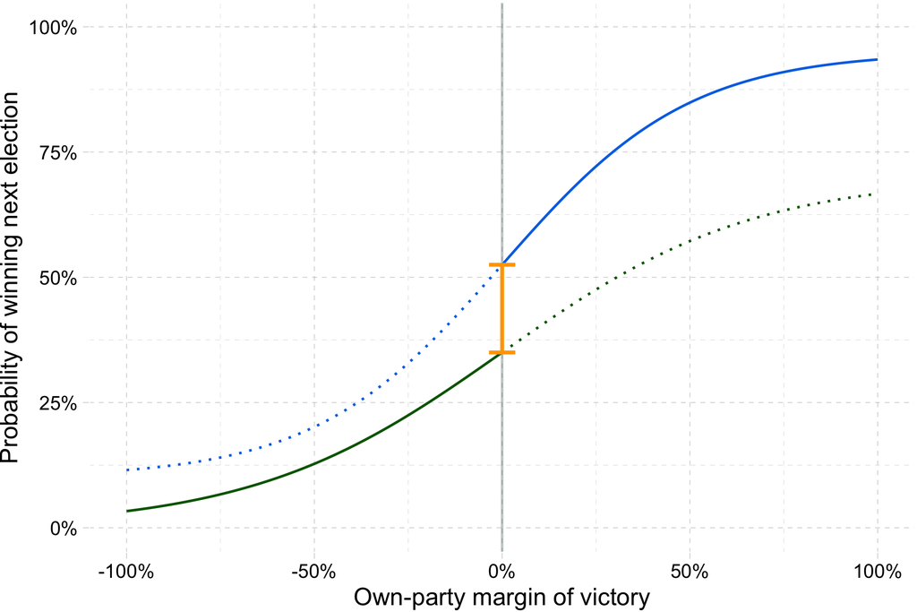

Real data are a bit trickier. We must estimate $\color{#0073e6}{\mathop{E}\left[ \text{Y}_{1i} \mid \text{X}_{i} \right]}$ and $\color{#006400}{\mathop{E}\left[ \text{Y}_{0i} \mid \text{X}_{i} \right]}$.

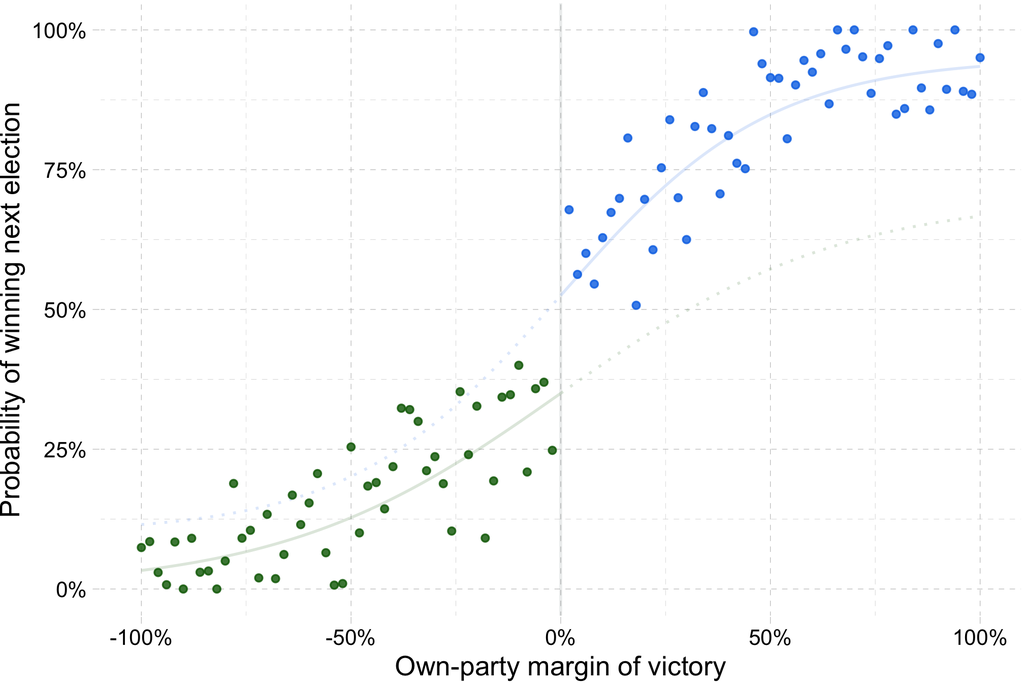

Questions

1. How should we estimate $\color{#0073e6}{\mathop{E}\left[ \text{Y}_{1i} \mid \text{X}_{i} \right]}$ and $\color{#006400}{\mathop{E}\left[ \text{Y}_{0i} \mid \text{X}_{i} \right]}$?
2. How much data should we use—*i.e.*, what is the right bandwidth size?

Option 1a Linear regression with constant slopes (and all data)

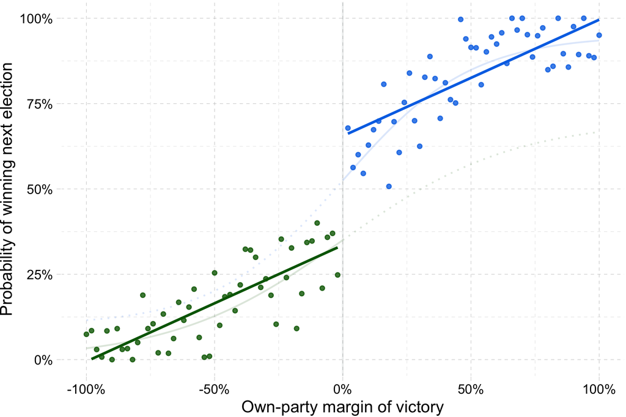

Option 1a Linear regression with constant slopes (and all data)

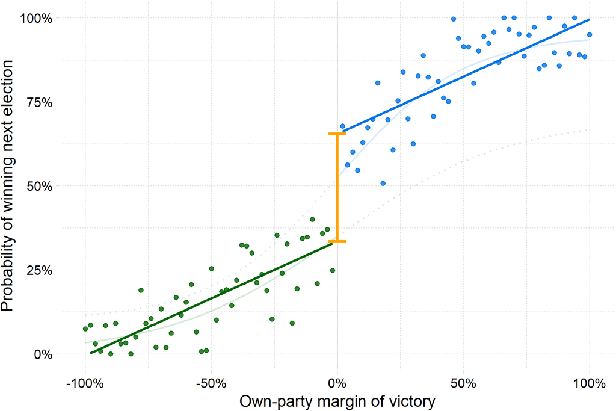

Option 1b Linear regression with constant slopes; limited to +/- 50%.

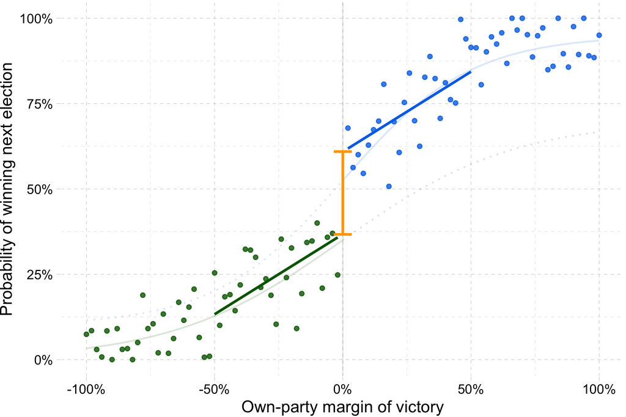

Option 2a Linear regression with differing slopes (and all data)

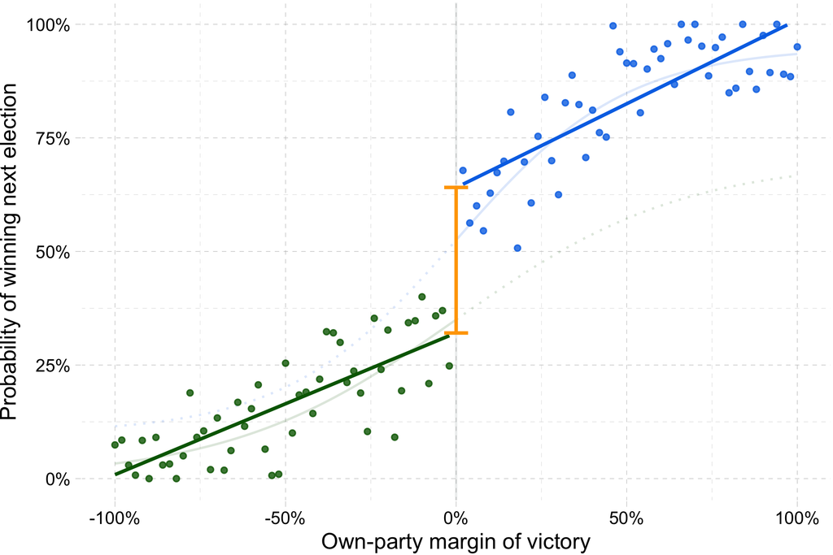

Option 2b Linear regression with differing slopes; limited to +/- 50%.

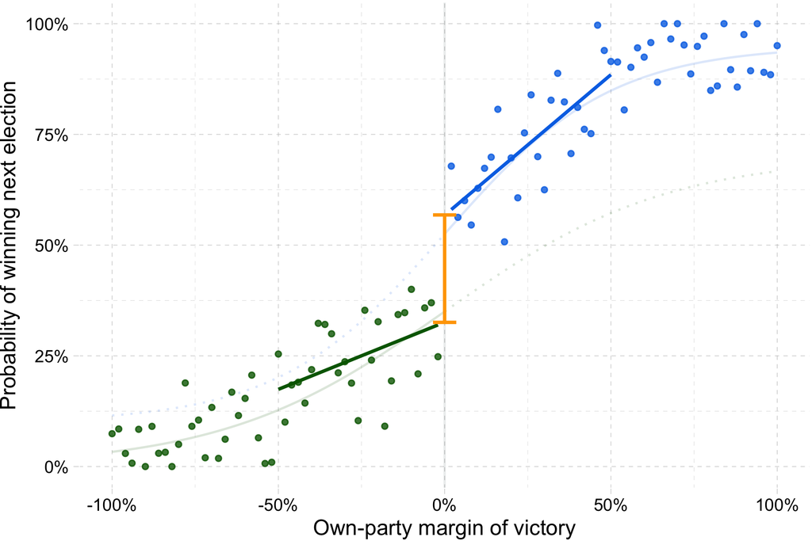

Option 2c Linear regression with differing slopes; limited to +/- 25%.

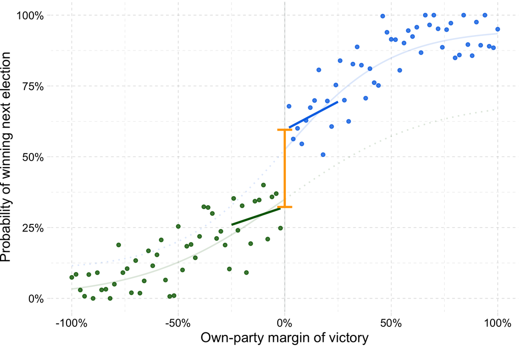

Option 3 Differing quadratic regressions (limited to +/- 50%).

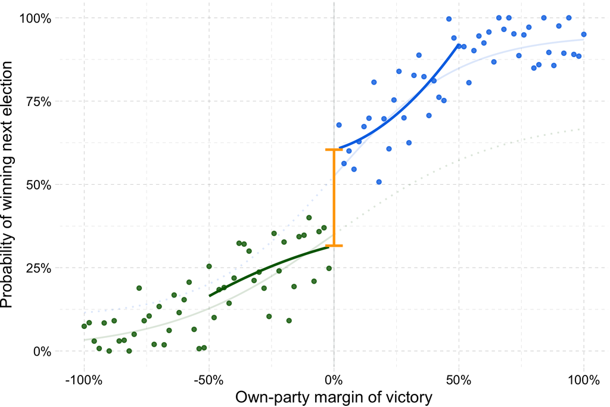

Option 4a Differing local (LOESS) regressions (limited to +/- 50%).

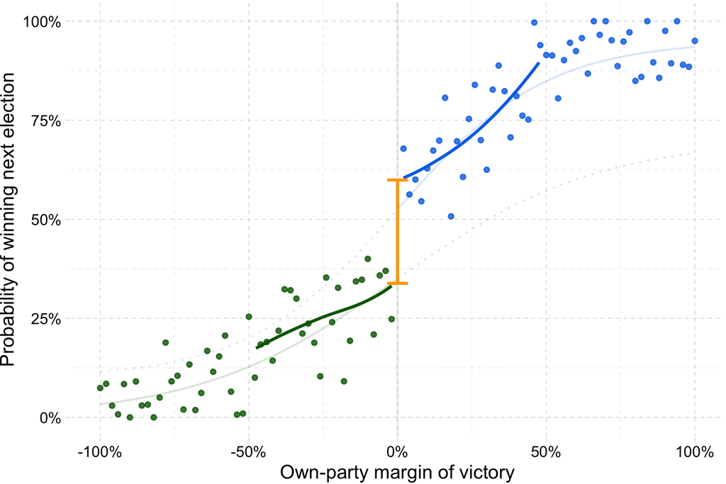

Option 4b Differing local (LOESS) regressions (all data).

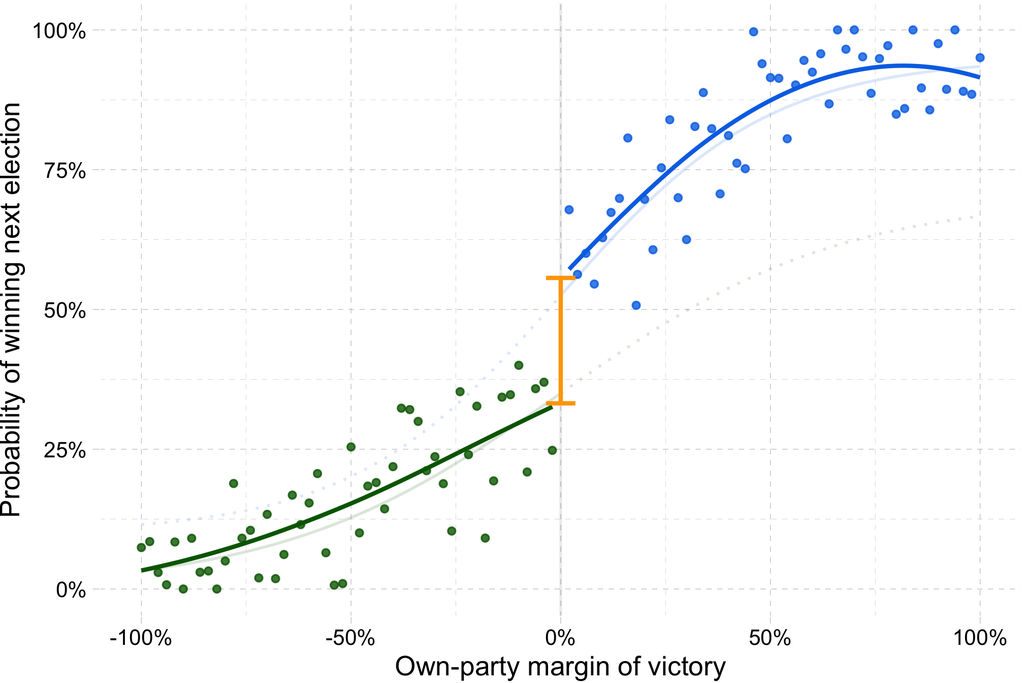

Note: Functional form can be very important.

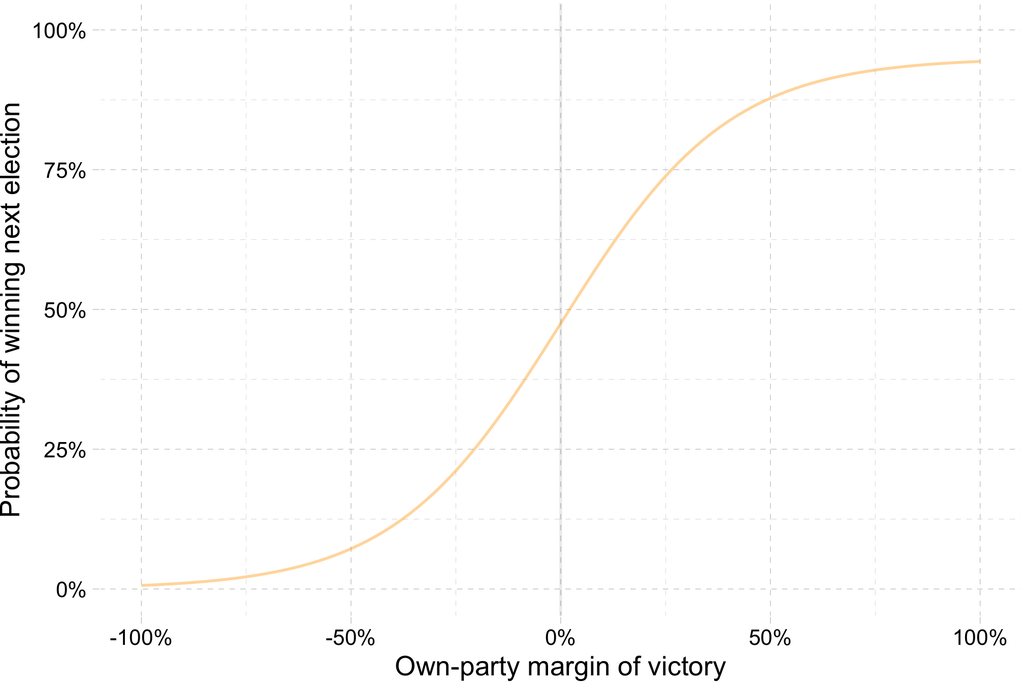

Note: Functional form can be very important.

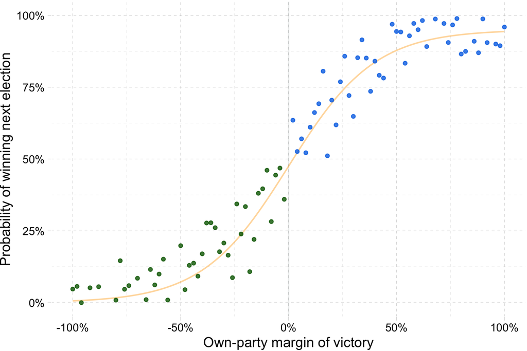

Note: Functional form can be very important.

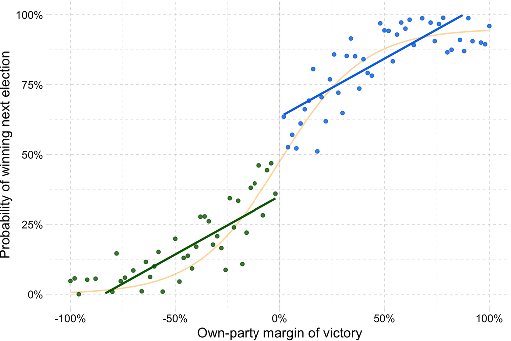

Note: Functional form can be very important.

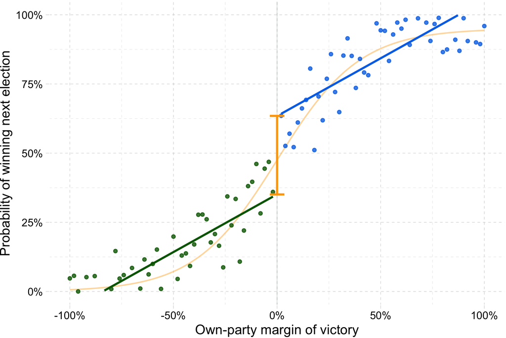

Note: Functional form can be very important.

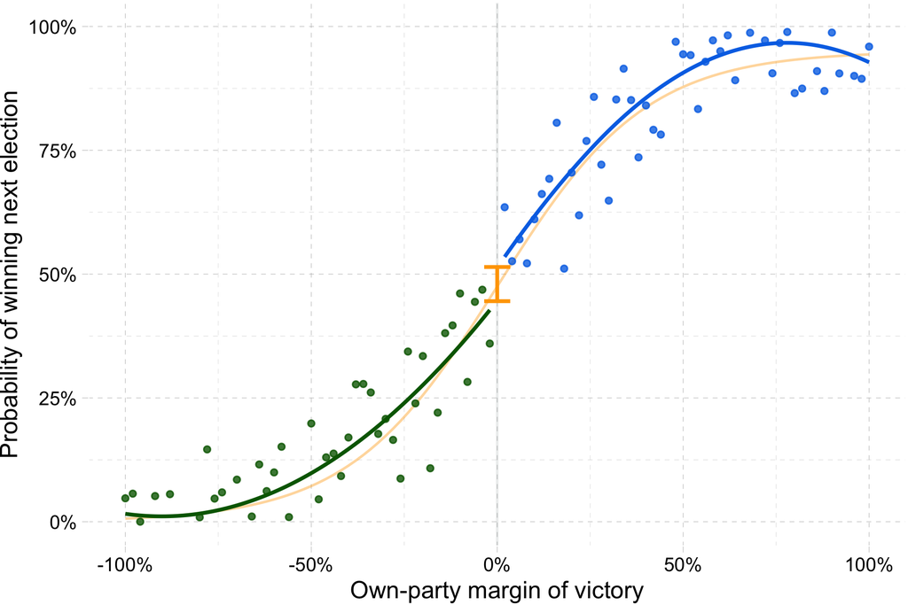

The continuity of $\color{#006400}{\mathop{E}\left[ \text{Y}_{0i}\mid \text{X}_{i} = x\right]}$ (in $x$) is also very important. No sorting.

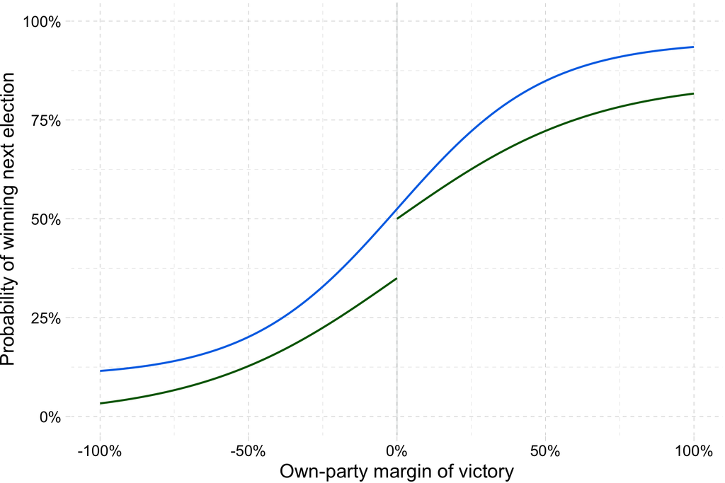

# Sharp RDs

## In practice

[Gelman and Imbens (2018)](https://amstat.tandfonline.com/doi/abs/10.1080/07350015.2017.1366909) on functional form:

> *We argue that controlling for global high-order polynomials in regression discontinuity analysis is a flawed approach with three major problems: it leads to noisy estimates, sensitivity to the degree of the polynomial, and poor coverage of confidence intervals. We recommend researchers instead use estimators based on local linear or quadratic polynomials or othersmooth functions.*

See [Imbens and Kalyanaraman (2012)](https://academic.oup.com/restud/article-abstract/79/3/933/1533189) for optimal bandwidth selection as well as Calonico et al ([2015](https://onlinelibrary.wiley.com/doi/abs/10.3982/ECTA11757);[2020](https://academic.oup.com/ectj/advance-article/doi/10.1093/ectj/utz022/5625071))

## Estimation

1. Trim data to a reasonable* window around the threshold $c$.
2. Recode $\color{#0073e6}{\text{X}_{i}}$ (the “forcing variable”) as deviation from $c$, *i.e.*, $\widetilde{\text{X}}_i = \text{X}_{i} - c$
- $\widetilde{\text{X}}_{i} = 0$ if $\text{X}_{i}=c$
- $\widetilde{\text{X}}_{i} < 0$ if $\text{X}_{i}<c$ and thus $\text{D}_{i}=0$
- $\widetilde{\text{X}}_{i} > 0$ if $\text{X}_{i}>c$ and thus $\text{D}_{i}=1$
3. Determine a model to estimate $\color{#0073e6}{\mathop{E}\left[ \text{Y}_{i} \mid \widetilde{\text{X}}_i \right]}$ for $\widetilde{\text{X}}_{i}$ above and below 0
- Linear with common slopes for $\mathop{E}\left[ \text{Y}_{i}\mid \widetilde{\text{X}}_i < 0 \right]$ and $\mathop{E}\left[ \text{Y}_{i}\mid \widetilde{\text{X}}_i > 0 \right]$
- Linear/quadratic/polynomial with differing slopes
- LOESS, kernel regression, *etc.*  
  * There is a lot of discussion on what is “reasonable”.

## Estimation: Linear, common slope

Assumptions

1. $\color{#006400}{\mathop{E}\left[\text{Y}_{0i} | \text{X}_{i} = x\right]}$ is linear in $x$, *i.e.*, $\color{#006400}{\mathop{E}\left[ \text{Y}_{0i} \mid \text{X}_{i} \right]} = \color{#006400}{\alpha + \beta \text{X}_{i}}$
2. Treatment effect does not depend upon $\text{X}_{i}$, *i.e.*, $\mathop{E}\left[ \text{Y}_{1i} - \text{Y}_{0i} \mid \text{X}_{i} \right] = \tau$  
   where (1) comes from linearity and (2) comes from common slopes.

$\implies \color{#0073e6}{\mathop{E}\left[ \text{Y}_{1i} \mid \text{X}_{i} \right]} = \tau + \color{#006400}{\mathop{E}\left[ \text{Y}_{0i} \mid \text{X}_{i} \right]} = \tau + \color{#006400}{\alpha + \beta \text{X}_{i}}$

$\color{#0073e6}{\mathop{E}\left[ \text{Y}_{1i} \mid \text{X}_{i} \right]} = \tau + \color{#006400}{\mathop{E}\left[ \text{Y}_{0i} \mid \text{X}_{i} \right]} = \tau + \color{#006400}{\alpha + \beta \text{X}_{i}}$

Recall our definition of $\text{Y}_{i} = \text{D}_{i} \color{#0073e6}{\text{Y}_{1i}} + (1-\text{D}_{i}) \color{#006400}{\text{Y}_{0i}}$.

$\mathop{E}\left[ \text{Y}_{i} \mid \text{X}_{i},\,\text{D}_{i} \right] = \text{D}_{i} \color{#0073e6}{\mathop{E}\left[ \text{Y}_{1i}\mid \text{X}_{i} \right]} + (1- \text{D}_{i})\color{#006400}{\mathop{E}\left[ \text{Y}_{0i}\mid \text{X}_{i} \right]}$

$\quad = \alpha + \tau \text{D}_{i} + \beta \text{X}_{i}$

$= \alpha + \tau \text{D}_{i} + \beta \left(\widetilde{\text{X}}_{i} + c\right)$

$= \widetilde{\alpha} + \tau \text{D}_{i} + \beta \widetilde{\text{X}}_{i}$

which we can estimate by regressing $\text{Y}_{i}$ on $\text{D}_{i}$ and $\widetilde{\text{X}}_{i}$.

## Estimation: Linear, differing slopes

Assumption $\color{#006400}{\mathop{E}\left[\text{Y}_{0i} | \text{X}_{i} = x\right]}$ and $\color{#0073e6}{\mathop{E}\left[\text{Y}_{1i} | \text{X}_{i} = x\right]}$ are linear in $x$, *i.e.*, $\color{#006400}{\mathop{E}\left[ \text{Y}_{0i} \mid \text{X}_{i} \right]} = \color{#006400}{\alpha_0 + \beta_0 \text{X}_{i}}$ and $\color{#0073e6}{\mathop{E}\left[ \text{Y}_{1i} \mid \text{X}_{i} \right]} = \color{#0073e6}{\alpha_1 + \beta_1 \text{X}_{i}}$

Now treatment effects can vary with $\text{X}_{i}$.

$\implies \mathop{E}\left[\color{#0073e6}{\text{Y}_{1i}} - \color{#006400}{\text{Y}_{0i}} \mid \text{X}_{i} \right] = \left( \alpha_1 - \alpha_0 \right) + \left( \beta_1 - \beta_0 \right)\text{X}_{i}$

$\mathop{E}\left[ \text{Y}_{i} \mid \text{X}_{i},\,\text{D}_{i} \right] = \text{D}_{i} \color{#0073e6}{\mathop{E}\left[ \text{Y}_{1i}\mid \text{X}_{i} \right]} + (1- \text{D}_{i})\color{#006400}{\mathop{E}\left[ \text{Y}_{0i}\mid \text{X}_{i} \right]}$

$\color{#ffffff}{\mathop{E}\left[ \text{Y}_{i} \mid \text{X}_{i},\,\text{D}_{i} \right]}= \color{#006400}{\alpha_0 + \beta_0 \text{X}_{i}} + (\color{#0073e6}{\alpha_1} - \color{#006400}{\alpha_0})\text{D}_{i} + (\color{#0073e6}{\beta_1} - \color{#006400}{\beta_0})\text{D}_{i}\text{X}_{i} \color{#ffffff}{\bigg|}$

$\color{#ffffff}{\mathop{E}\left[ \text{Y}_{i} \mid \text{X}_{i},\,\text{D}_{i} \right]}= \widetilde{\alpha} + \beta_0 \widetilde{\text{X}}_{i} + \tau \text{D}_{i} + \widetilde{\beta}\text{D}_{i}\widetilde{\text{X}}_{i}$

$\tau$ is the LATE at $\widetilde{\text{X}}_{i} = 0$ $\left(\text{X}_{i}=c\right)$.

Estimate: Regress $\text{Y}_{i}$ on $\widetilde{\text{X}}_{i}$, $\text{D}_{i}$, and $\text{D}_{i}\widetilde{\text{X}}_{i}$.

# Fuzzy RDs

## Setup

As with their sharp-RD relatives, fuzzy RDs take advantage of a discontinuous change in treatment assignment across some threshold $c$.

In a fuzzy regression discontinuity, the *probability* of treatment changes discontinuously as $\text{X}_{i}$ crosses $c$, but it is no longer deterministic.

Formally,
$$\begin{align}
0 < \lim_{x\downarrow c} \mathop{\text{Pr}}\left(\text{D}_{i} = 1\mid \text{X}_{i} = x\right) - \lim_{x\uparrow c} \mathop{\text{Pr}}\left(\text{D}_{i} = 1\mid \text{X}_{i} = x\right) < 1
\end{align}$$

*Ex.*, Exceeding a minimum GRE requirement for graduate school.

## Threshold effects

We now have **two effects** of $\text{X}_{i}$ crossing our threshold $c$.

1. The effect of $\text{X}_{i}$ crossing $c$ on our outcome
   $$\begin{align}
   \color{#3b3b9a}{\lim_{x\downarrow c} \mathop{E}\left[\text{Y}_{i}\mid \text{X}_{i} = x\right] - \lim_{x\uparrow c} \mathop{E}\left[\text{Y}_{i}\mid \text{X}_{i} = x\right]}
   \end{align}$$
2. The effect of $\text{X}_{i}$ crossing $c$ on the probability of treatment
   $$\begin{align}
   \color{#20B2AA}{\lim_{x\downarrow c} \mathop{E}\left[\text{D}_{i}\mid \text{X}_{i} = x\right] - \lim_{x\uparrow c} \mathop{E}\left[\text{D}_{i}\mid \text{X}_{i} = x\right]}
   \end{align}$$

The treatment effect defined by a fuzzy RD is the ratio of (1) to (2)
$$\begin{align}
\tau_\text{FRD} = \dfrac{\color{#3b3b9a}{\lim_{x\downarrow c} \mathop{E}\left[\text{Y}_{i}\mid \text{X}_{i} = x\right] - \lim_{x\uparrow c} \mathop{E}\left[\text{Y}_{i}\mid \text{X}_{i} = x\right]}}{\color{#20B2AA}{\lim_{x\downarrow c} \mathop{E}\left[\text{D}_{i}\mid \text{X}_{i} = x\right] - \lim_{x\uparrow c} \mathop{E}\left[\text{D}_{i}\mid \text{X}_{i} = x\right]}}
\end{align}$$

## An old friend

This definition of the fuzzy-RD treatment effect
$$\begin{align}
\tau_\text{FRD} = \dfrac{\color{#3b3b9a}{\lim_{x\downarrow c} \mathop{E}\left[\text{Y}_{i}\mid \text{X}_{i} = x\right] - \lim_{x\uparrow c} \mathop{E}\left[\text{Y}_{i}\mid \text{X}_{i} = x\right]}}{\color{#20B2AA}{\lim_{x\downarrow c} \mathop{E}\left[\text{D}_{i}\mid \text{X}_{i} = x\right] - \lim_{x\uparrow c} \mathop{E}\left[\text{D}_{i}\mid \text{X}_{i} = x\right]}}
\end{align}$$
should remind you of something

—IV, where $\text{Z}_{i} = \mathbb{I}\left\{ \text{X}_{i}\geq c \right\}$.

Accordingly, fuzzy RDs are going to have the same requirements and interpretation as IV.

## More formally

Let $\text{D}_{i}\left( x^* \right)$ denote the potential treatment status of $i$ with threshold $\color{#314f4f}{x^*}$.

Why write potential treatment status $\text{D}_{i}$ a function of the threshold?

Changing the threshold (*e.g.*, voting age) generally makes more sense than changing $\text{X}_{i}$ (*e.g.*, age).*

*I.e.*, changing the threshold changes treatment statuses at the margin.

Assumption $\text{D}_{i}\left(x^*\right)$ is non-increasing in $x^*$ at $x^*=c$.

This is our monotonicity assumption for fuzzy RDs.

If we raise $x^*$ from $c$ to $c+\epsilon$, no one joins treatment—no defiers.

* This observation/motivation can help with inference.

## Compliance

Our compliers in this setting are individuals such that

$$\begin{align}
&\lim_{x^*\downarrow \text{X}_{i}} \text{D}_{i}\left( x^* \right) = 0
&\lim_{x^*\uparrow \text{X}_{i}} \text{D}_{i}\left( x^* \right) = 1
\end{align}$$

- compliers are only treated when $x^*$ (the threshold) is *below* their $\text{X}_{i}$.
  - *e.g.* a student is accepted only because their GRE scores were above some threshold (700), otherwise they would have been rejected.

$\tau_\text{FRD} = \dfrac{\lim_{x\downarrow c} \mathop{E}\left[\text{Y}_{i}\mid \text{X}_{i} = x\right] - \lim_{x\uparrow c} \mathop{E}\left[\text{Y}_{i}\mid \text{X}_{i} = x\right]}{\lim_{x\downarrow c} \mathop{E}\left[\text{D}_{i}\mid \text{X}_{i} = x\right] - \lim_{x\uparrow c} \mathop{E}\left[\text{D}_{i}\mid \text{X}_{i} = x\right]}$

$\color{#ffffff}{\tau_\text{FRD}}= \mathop{E}[ \color{#0073e6}{\text{Y}_{1i}} - \color{#006400}{\text{Y}_{0i}} | i$ is a complier and $\text{X}_{i}=c$.

Thus, $\tau_\text{FRD}$ can be a *very local* LATE.

# Graphical analysis

## General

RD analyses hinge on their graphical analyses.

If the discontinuity is not graphically apparent, most people are not going to care about the results of a few tortured regressions.

You’re arguing you know that treatment assignment changes across the threshold. If your reader/viewer cannot see it, they’re likely not going to believe your regression tables.

This skepticism may be well founded. We know RDs are sensitive to functional form—and researchers have been known to *p-hack*.

## Three figures

Most RD analyses will have some subset of three (of four) types of figures.

1. Outcomes by the running/forcing variable $\left( \text{X}_{i} \right)$
- Do we observe a treatment effect across the discontinuity?
2. Treatment by the running/forcing variable (fuzzy RD only) $\left( \text{X}_{i} \right)$
- Does the discontinuity in fact change the probability of treatment?
3. Covariates by the running/forcing variable $\left( \text{X}_{i} \right)$
- Are covariates smooth/balanced across the discontinuity?
4. Density of running/forcing variable $\left( \text{X}_{i} \right)$
- Is there evidence of sorting into treatment (across the threshold)?

## Outcomes by running variable

These figures tend to show the average value of the outcome $\text{Y}_{i}$ at evenly spaced bins of the running variable $\text{X}_{i}$.

We have two parameter choices

1. Binwidth $\left( h \right)$
2. Numbers of bins below and above threshold $\left( K_0,\, K_1 \right)$

that yield $K=K_0+K_1$ bins $\left( k=1,\, \ldots,\, K \right)$
$$\begin{align}
b_k = c - \left( K_0 - k + 1 \right) \times h
\end{align}$$

We then calculate summaries for each bin.

## Outcomes by running variable

The bin’s number of observations, $N_k$
$$\begin{align}
N_k = \sum_{i=1}^N \mathbb{I}\left\{ b_k < \text{X}_{i} \le b_{k+1} \right\}
\end{align}$$

The average treatment level in the bin, $\overline{D}_k$ (for fuzzy RDs)
$$\begin{align}
\overline{D}_k = \dfrac{1}{N_k} \sum_{i=1}^N \text{D}_{i} \times \mathbb{I}\left\{ b_k < \text{X}_{i} \le b_{k+1} \right\}
\end{align}$$

The average outcome in the bin, $\overline{Y}_k$
$$\begin{align}
\overline{Y}_k = \dfrac{1}{N_k} \sum_{i=1}^N \text{Y}_{i} \times \mathbb{I}\left\{ b_k < \text{X}_{i} \le b_{k+1} \right\}
\end{align}$$

## Outcomes by running variable

Plot $\overline{\text{Y}}_k$ against the midpoint of each bin.

Q1: Does crossing $c$ clearly affect our outcome $\text{Y}_{i}$? (Fuzzy RD reduced form)

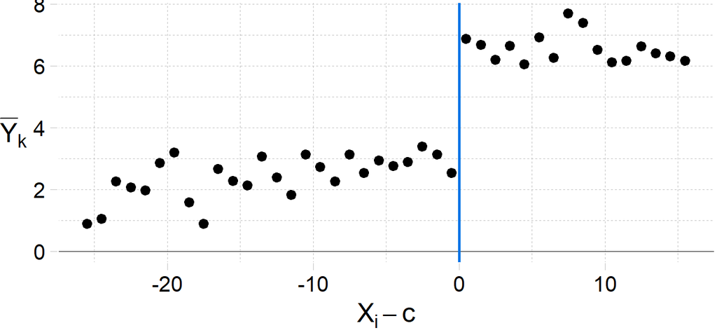

## Treatment by running variable

Plot $\overline{\text{D}}_k$ against the midpoint of each bin.

Q1a: Does crossing $c$ clearly affect $\mathop{\text{Pr}}\left(\text{D}_{i}=1\right)$? (Fuzzy RD first stage)

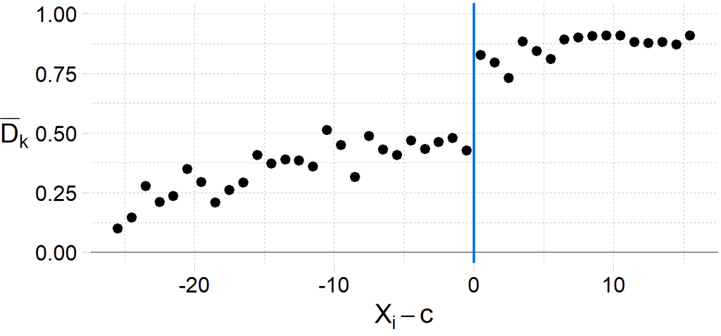

## Covariates by running variable

Now we apply the same approach to covariates $\left( \text{Z}_{i} \right)$.

Q2: Are covariates smooth across $c$? If not, your RD may be invalid.

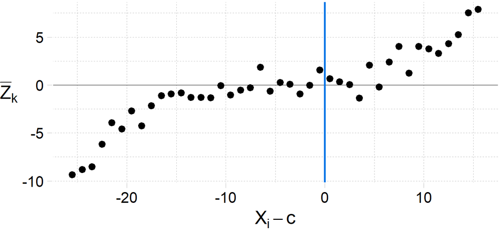

## Density of running variable

Finally we looking for other violations of smoothness—particularly by potentially gaming the threshold.

Are individuals bunching just above or just below the threshold?

If so, folks just below the threshold don’t give us the clean counterfactual for the folks just above the threshold.

McCrary (2008) suggests testing the density of $\text{X}_{i}$ at $c$.

## Density of running variable

Effectively, we can plot $N_k$ at the midpoint of each bin.

Q3 Is the distribution of $\text{X}_{i}$ smooth across $c$?

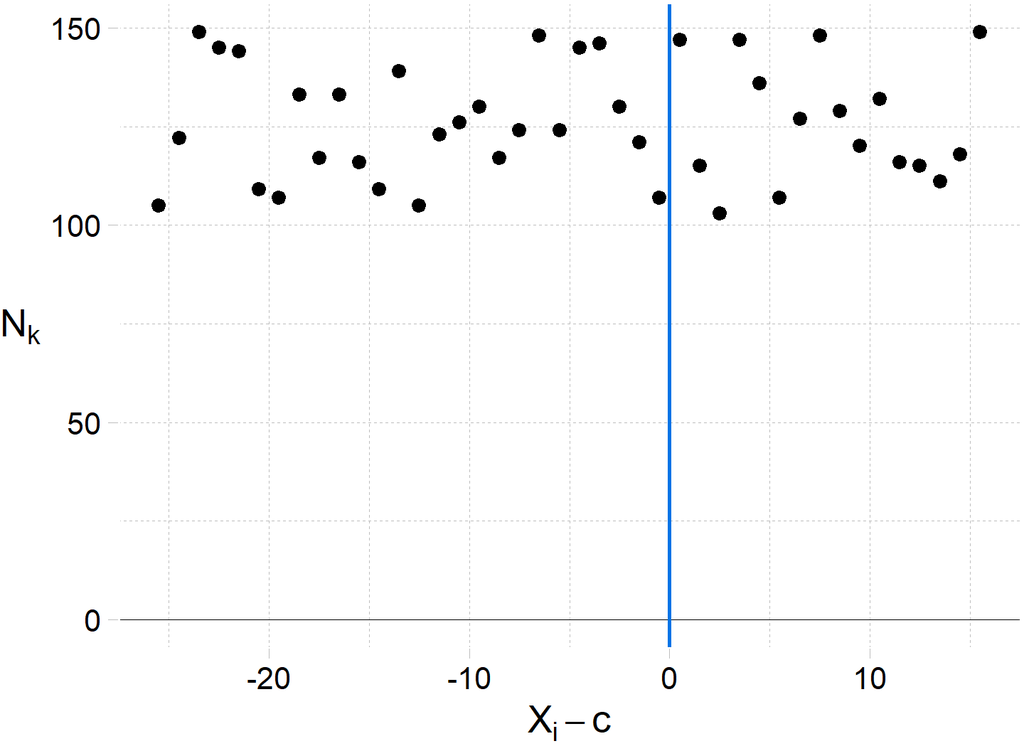

## Density of running variable

Likely bunching (problem)

Q3 Is the distribution of $\text{X}_{i}$ smooth across $c$?

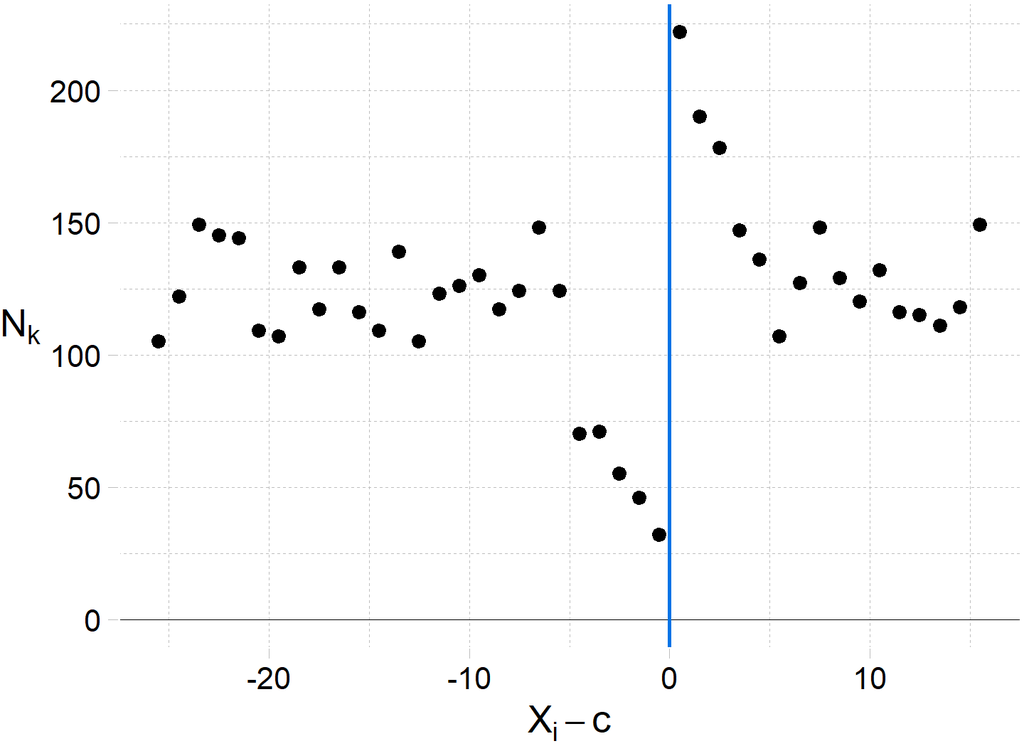

Q3: Is the density of $\text{X}_{i}$ smooth near $c$?

Looks good!

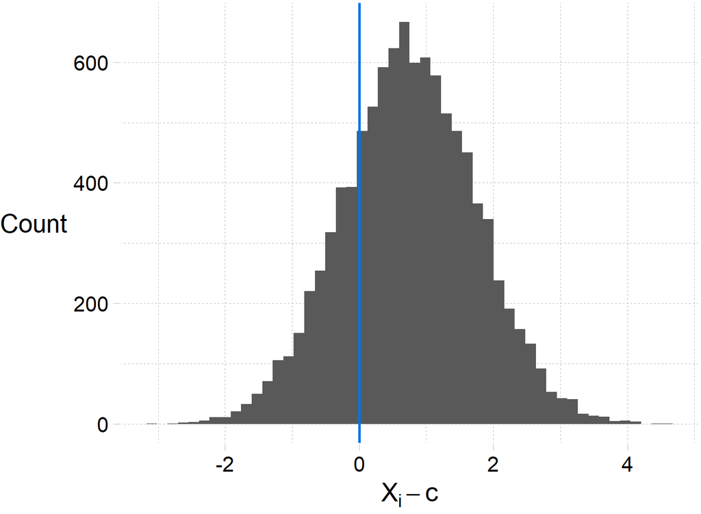

Q3: Is the density of $\text{X}_{i}$ smooth near $c$?

Problem with bunching.

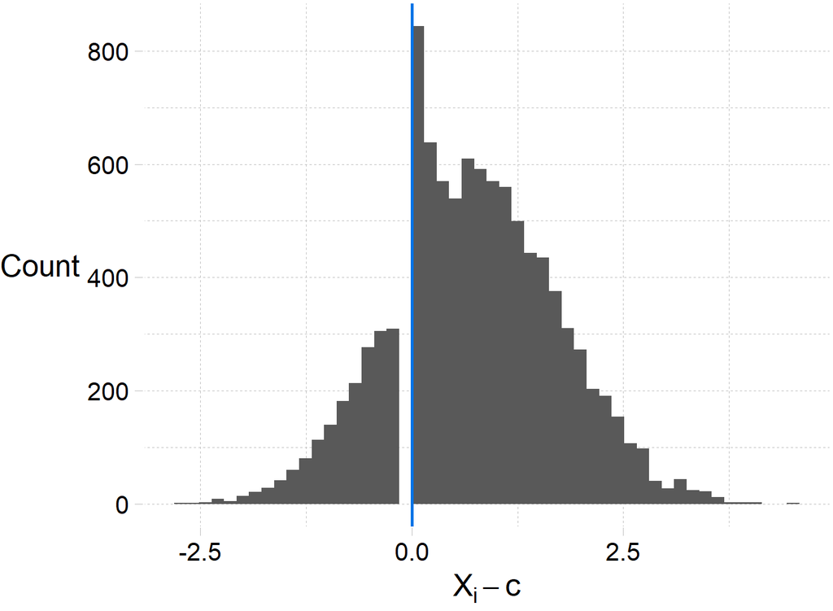

## Additional points

1. No bin should cross the threshold.
2. Are there discontinuities other than $c$? Should there be? Smoothness?

# Optimal Bandwidths and Data-Driven RD Plots

## Optimal Bandwidths and Data-Driven RD Plots

- Modern RD practice separates two tasks:
  - **point estimation** of the discontinuity
  - **valid inference** on that discontinuity
- The key tuning parameter is the **bandwidth** $h$: how much data near the cutoff we use.
- Too small $h$:
  - low bias
  - high variance
- Too large $h$:
  - lower variance
  - more smoothing bias
- The `rdrobust` framework makes this tradeoff **data-driven** rather than ad hoc.

## The importance of bandwidth

For a sharp RD,
$$\tau_{SRD}
=
\lim_{x \downarrow c} E[Y_i \mid X_i=x]
-
\lim_{x \uparrow c} E[Y_i \mid X_i=x].$$

Local polynomial RD estimates this jump using only observations with $X_i \in [c-h,\, c+h]$.

## The importance of bandwidth

**Intuition**

- RD is a **local extrapolation** problem at the cutoff.
- The bandwidth determines how “local” the comparison is.
- Choosing $h$ is therefore not cosmetic: it changes the estimator, the bias, the variance, and the confidence interval.

**Takeaway**

- In RD, “specification choice” is largely a **bandwidth choice**.
- `rdbwselect()` and `rdrobust()` formalize that choice.

## MSE-Optimal Bandwidth

Let $\hat\tau(h)$ be the local polynomial RD estimator.

The mean squared error criterion is
$$MSE(h) = \mathrm{Bias}(\hat\tau(h))^2 + \mathrm{Var}(\hat\tau(h)).$$

The **MSE-optimal bandwidth** $h_{MSE}$ chooses $h$ to minimize this tradeoff.

## MSE-Optimal Bandwidth

$$MSE(h) = \mathrm{Bias}(\hat\tau(h))^2 + \mathrm{Var}(\hat\tau(h)).$$

**Intuition**

- We want enough data to reduce noise,
- but not so much that curvature away from the cutoff biases the local comparison.

**Why this matters**

- $h_{MSE}$ is typically excellent for **estimating the jump**.
- But it is often **too large for conventional inference** because smoothing bias can remain non-negligible.
- If you estimate with $h_{MSE}$ and then use naive local-linear standard inference, confidence intervals can undercover.

## Optimal bandwidth and standard inference

MSE-optimal bandwidth balances **bias² + variance** for *point estimation* —  
it does **not** make bias negligible.

### What standard inference assumes

Naive local-linear CI:
$$\hat\tau(h) \pm 1.96 \cdot SE(\hat\tau(h))$$

This is valid only if:

- bias $\approx 0$ (asymptotically negligible)
- uncertainty is dominated by variance

### What actually happens at $h_{MSE}$

- $h_{MSE}$ is **relatively large** (to reduce variance)
  - smoothing bias is **non-negligible**
- estimator is centered at:
  $$E[\hat\tau(h_{MSE})] = \tau + \text{Bias}$$

So CI is centered at the **wrong value**

### Intuition

- You are fitting a smooth curve over a **curved regression function**
- Near the cutoff:
  - curvature ⇒ systematic misspecification
- Larger bandwidth:
  - more curvature included
  - ⇒ **bias grows**

### Why this causes undercoverage

Your CI:
$$[\hat\tau \pm 1.96 \cdot SE]$$

But truth is:
$$\tau = \hat\tau - \text{Bias}$$

If: $|\text{Bias}|$ is large relative to $SE$

Then: CI is **shifted away from truth**

- misses $\tau$ too often
- **coverage < 95% (undercoverage)**

## Practical implications:

- $h_{MSE}$ solves optimzes between bias and variance
- But inference needs:$\text{Bias} \ll SE$
  - These are **not the same objective**
- $h_{MSE}$ is great for **estimating the jump**
- but is **too large for naive inference**
- Solutoin:
  - either shrink bandwidth (inefficient), or
  - use **robust bias correction (preferred)**

> MSE-optimal bandwidth keeps bias small *relative to variance*,  
> but inference requires bias to be small *relative to the standard error*.

## Robust Bias Correction (RBC)

The robust RD papers show that conventional inference can fail with “large” bandwidths.

A stylized RBC interval is
$$\hat\tau(h_{MSE}) - \hat B
\;\pm\;
1.96 \sqrt{\hat V + \hat W},$$
where:

- $\hat B$ = estimated leading bias
- $\hat V$ = usual variance piece
- $\hat W$ = adjustment for extra uncertainty from estimating the bias

### Intuition

- Do **not** throw away data just to kill bias mechanically.
- Instead:
  1. estimate the bias,
  2. recenter the estimator,
  3. inflate the standard error appropriately.

### In practice

- `rdrobust()` implements this directly.
- This is why the package reports both:
  - **Conventional**
  - **Robust**

## Coverage Error (CER)-Optimal Bandwidth

There is a second bandwidth target: **coverage error**.

Instead of minimizing point-estimation MSE, choose $h$ to minimize how far the confidence interval’s actual coverage is from its nominal level.

**Conceptually**

- $h_{MSE}$: optimize the estimator
- $h_{CER}$: optimize the confidence interval

### Intuition

- A good point estimate is not automatically a good inferential procedure.
- CER-optimal bandwidths are typically **smaller** than MSE-optimal bandwidths because inference is more sensitive to bias.

### In practice

- Use $h_{MSE}$ when your emphasis is the point estimate.
- Use RBC inference by default.
- If inference is the main object, CER-based choices are especially attractive.

## RD Plots as data-driven binscatters

An RD plot combines:

- a **global polynomial fit** for visual shape
- **binned local means** to show local variation

The binned means are a special case of a **binscatter / partitioning estimator**.

Two main binning choices:

- **Evenly-spaced bins (ES):** all bins have the same width in $X$
  - ES is easy to read on the $x$-axis.
- **Quantile-spaced bins (QS):** bins have roughly the same number of observations
  - QS adapts better when the running variable is unevenly distributed.

## Choosing the Number of Bins

`rdplot()` offers two main data-driven criteria.

1. IMSE-optimal bins
- Choose the number of bins to minimize an integrated mean squared error criterion.
  - smoothly traces the regression function
  - shows global shape
2. Mimicking-variance (MV) bins
- Choose the number of bins so the binned means reflect the raw-data variability.
  - shows true noise in data
  - avoids plots that look “too smooth”